# What Makes a Pokémon Good?

By Nicholas Levin

Ever since the first Pokémon game was released in 1996, Pokémon has been one of Nintendo's most successful franchises [with over 380 million copies sold](https://www.pastemagazine.com/games/nintendo/best-selling-nintendo-franchises/#2-pok%C3%A9mon). As more consoles have released, and Pokémon continues to grow as a franchise, one thing remains constant: a Pokémon competitive scene.

Competitive Pokémon battling first came to life in the early 2000s, though it was still a relatively new concept. The competitions stayed in small circles until 2009, when The Pokémon Company held a World Championship for the first time. Ever since that, competitive Pokémon battle has exploded, allowing players to win cash prizes even up to $10,000. The competitive scene stays exciting with more and more Pokémon being brought into the fold with the release of each new generation, and clever players are always shaking up the game with new strategies. What started as a humble 151 Pokémon, has now ballooned to a huge 905, a number expected to increase with the new generation on the horizon.

Unfortunately, not all Pokémon are as good as others in the competitive scene. Type, stats, abilities, and a numerous other factors go in to determining a Pokémon's viability. Pokémon Showdown, an online competitive battle simulator made by Smogon, ranks each Pokémon in the following tiers determined by how often they are used in battle: Ubers, Overused, Underused, Rarely Used, Never Used, and Partially Used. There are also tiers in between them for Pokémon who are considered in between tiers. But with new Pokémon on the horizon, how will we be able to determine their viability, since they don't have usage stats yet? To do this, I need the answer the following question: "what makes a Pokémon good?" With that information, I will try to build a model to predict what tier a new Pokémon would be placed in, keeping a step ahead of the rest of the competitive scene.

## Looking at the Data

I will be using a dataset from data.world that [lists all fully evolved Pokémon, alongside their tier as reported by Pokémon Showdown](https://data.world/notgibs/smogon-6-v-6-pokemon-tiers). This dataset also includes a slew of other helpful information, such as stat distributions, and types. I will use the pandas library to read the data from the csv into a dataframe that I can work with. I also decided to replace NaN in the Type.2 column with the string "None," since I also wanted to consider no second typing as a type itself.

```python
import pandas as pd
from matplotlib import pyplot as plt
import numpy as np
from collections import defaultdict
from sklearn.linear_model import LogisticRegression
from sklearn.model_selection import train_test_split
from sklearn.model_selection import cross_val_score
from sklearn.pipeline import make_pipeline
from sklearn.preprocessing import StandardScaler
from sklearn.metrics import make_scorer

df = pd.read_csv("smogon.csv")
df['Type.2'] = df['Type.2'].fillna("None")
df
```

|  | X. | Name | Type.1 | Type.2 | Total | HP | Attack | Defense | Sp..Atk | Sp..Def | Speed | Generation | Legendary | Mega | Tier |
| --- | --- | --- | --- | --- | --- | --- | --- | --- | --- | --- | --- | --- | --- | --- | --- |
| 0 | 384 | Mega Rayquaza | Dragon | Flying | 780 | 105 | 180 | 100 | 180 | 100 | 115 | 3 | True | True | AG |
| 1 | 94 | Mega Gengar | Ghost | Poison | 600 | 60 | 65 | 80 | 170 | 95 | 130 | 1 | False | True | Uber |
| 2 | 115 | Mega Kangaskhan | Normal | None | 590 | 105 | 125 | 100 | 60 | 100 | 100 | 1 | False | True | Uber |
| 3 | 150 | Mewtwo | Psychic | None | 680 | 106 | 110 | 90 | 154 | 90 | 130 | 1 | True | False | Uber |
| 4 | 150 | Mega Mewtwo X | Psychic | Fighting | 780 | 106 | 190 | 100 | 154 | 100 | 130 | 1 | True | True | Uber |
| ... | ... | ... | ... | ... | ... | ... | ... | ... | ... | ... | ... | ... | ... | ... | ... |
| 494 | 479 | Rotom-F | Electric | Ice | 520 | 50 | 65 | 107 | 105 | 107 | 86 | 4 | False | False | PU |
| 495 | 479 | Rotom-S | Electric | Flying | 520 | 50 | 65 | 107 | 105 | 107 | 86 | 4 | False | False | PU |
| 496 | 413 | Wormadam-Plant | Bug | Grass | 424 | 60 | 59 | 85 | 79 | 105 | 36 | 4 | False | False | PU |
| 497 | 413 | Wormadam-Sandy | Bug | Ground | 424 | 60 | 79 | 105 | 59 | 85 | 36 | 4 | False | False | PU |
| 498 | 413 | Wormadam-Trash | Bug | Steel | 424 | 60 | 69 | 95 | 69 | 95 | 36 | 4 | False | False | PU |

499 rows × 15 columns

## Data Visualization and Analysis

The first metric for determining a Pokémon's viability that I gravitated to was the stat total. It makes sense that Pokémon with a higher stat total, and thus stronger over all, would be in higher tiers. To test if this is true, I make a violin plot showing the distribution of stat totals for each tier. I also plot a regression line to show any relation.

```
['AG', 'Uber', 'OU', 'BL', 'UU', 'BL2', 'RU', 'BL3', 'NU', 'BL4', 'PU']
```

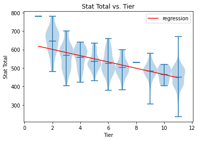

```python
tiers = []
stat_totals_per_tier = []
tier_to_num = {}
i = 1
for tier in df["Tier"].unique():
    tiers.append(tier)
    tier_to_num[tier] = i
    i += 1

    mask = df["Tier"] == tier
    stat_totals_per_tier.append([i for i in df[mask]["Total"]])

df['Tier_Num'] = df["Tier"].apply(lambda x: tier_to_num[x])
d = np.polyfit(df['Tier_Num'], df['Total'], 1)
f = np.poly1d(d)
df['regression'] = f(df['Tier_Num'])

fig, ax = plt.subplots()
print(tiers)

ax.violinplot(stat_totals_per_tier,tier_to_num.values(),widths=1,showmeans=True)
ax.set_title("Stat Total vs. Tier")
ax = df.plot(x = 'Tier_Num', y = 'regression', ax=ax, color='Red')
ax.set_xlabel("Tier")
ax.set_ylabel("Stat Total")

fig.savefig("violin.png")
```

From the plot, we can see that there is a relationship between the total stat distribution and the tier. As expected, the lower the stat total, the lower the tier. However, this relationship is clearly not sufficient for determining a Pokémon's tier. There is a huge range of stat totals for each tier. Ubers roughly has anywhere from 500-800 total stats, which is quite a wide range. Even the lowest tier, PU, can have up to almost 700 total stat.

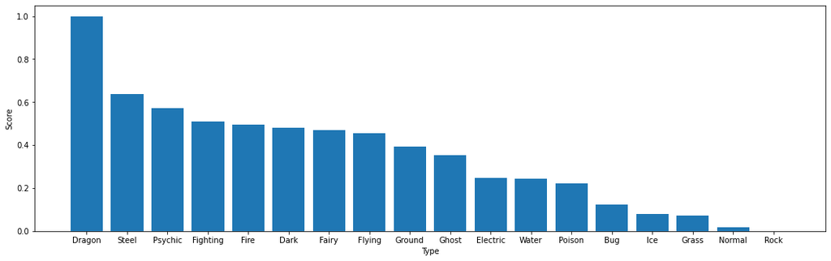

```python
scores = defaultdict(lambda: 0)
count = defaultdict(lambda: 0)
for index, row in df.iterrows():
    scores[row["Type.1"]] += 1 / (row["Tier_Num"] * 1.0)
    count[row["Type.1"]] += 1

    if row["Type.2"] != "None":
        scores[row["Type.2"]] += 1 / (row["Tier_Num"] * 1.0)
        count[row["Type.2"]] += 1

for key in scores:
    scores[key] = scores[key] / count[key]

maximum = max(scores.values())
minimum = min(scores.values())
for key in scores:
    scores[key] = (scores[key] - minimum) / (maximum - minimum)

scores = dict(sorted(scores.items(), key=lambda item: item[1], reverse=True))

fig = plt.figure()
fig.set_figwidth(14)
ax = fig.add_axes([0, 0, 1, 1])
ax.set_ylabel("Score")
ax.set_xlabel("Type")
ax.bar(scores.keys(), scores.values())
plt.show()
```

From the bar graph, we can see that there are clearly some types that dominate higher tiers over other types. Dragon Type is highly popular because of the amazing defensive and offensive capabilities, and Rock Type is weaker because of how many weaknesses it has.

```python
types = list(scores.keys())
type_chart = pd.read_csv("Pokemon Type Chart.csv", index_col=[0])
tier_matchup_data = {}
for tier in df["Tier"].unique():
    strengths = 0
    weaknesses = 0
    num_pokemon = 0
    mask = df['Tier'] == tier
    for index, pokemon in df[mask].iterrows():
        if pokemon['Type.2'] == "None":
            for type in types:
                if type_chart.loc[pokemon['Type.1'], type] > 1:
                    strengths += 1
                if type_chart.loc[type, pokemon['Type.1']] > 1:
                    weaknesses += 1
        else:
            for type in types:
                if type_chart.loc[pokemon['Type.1'], type] > 1 or type_chart.loc[pokemon['Type.2'], type] > 1:
                    strengths += 1
                if type_chart.loc[type, pokemon['Type.1']] * type_chart.loc[type, pokemon['Type.2']] > 1:
                    weaknesses += type_chart.loc[type, pokemon['Type.2']] * type_chart.loc[type, pokemon['Type.2']] / 2

        num_pokemon += 1

    tier_matchup_data[tier] = [strengths / num_pokemon, weaknesses / num_pokemon]

type_chart
```

|  | Normal | Fire | Water | Electric | Grass | Ice | Fighting | Poison | Ground | Flying | Psychic | Bug | Rock | Ghost | Dragon | Dark | Steel | Fairy |
| --- | --- | --- | --- | --- | --- | --- | --- | --- | --- | --- | --- | --- | --- | --- | --- | --- | --- | --- |
| Normal | 1.0 | 1.0 | 1.0 | 1.0 | 1.0 | 1.0 | 1.0 | 1.0 | 1.0 | 1.0 | 1.0 | 1.0 | 0.5 | 0.0 | 1.0 | 1.0 | 0.5 | 1.0 |
| Fire | 1.0 | 0.5 | 0.5 | 1.0 | 2.0 | 2.0 | 1.0 | 1.0 | 1.0 | 1.0 | 1.0 | 2.0 | 0.5 | 1.0 | 0.5 | 1.0 | 2.0 | 1.0 |
| Water | 1.0 | 2.0 | 0.5 | 1.0 | 0.5 | 1.0 | 1.0 | 1.0 | 2.0 | 1.0 | 1.0 | 1.0 | 2.0 | 1.0 | 0.5 | 1.0 | 1.0 | 1.0 |
| Electric | 1.0 | 1.0 | 2.0 | 0.5 | 0.5 | 1.0 | 1.0 | 1.0 | 0.0 | 2.0 | 1.0 | 1.0 | 1.0 | 1.0 | 0.5 | 1.0 | 1.0 | 1.0 |
| Grass | 1.0 | 0.5 | 2.0 | 1.0 | 0.5 | 1.0 | 1.0 | 0.5 | 2.0 | 0.5 | 1.0 | 0.5 | 2.0 | 1.0 | 0.5 | 1.0 | 0.5 | 1.0 |
| Ice | 1.0 | 0.5 | 0.5 | 1.0 | 2.0 | 0.5 | 1.0 | 1.0 | 2.0 | 2.0 | 1.0 | 1.0 | 1.0 | 1.0 | 2.0 | 1.0 | 0.5 | 1.0 |
| Fighting | 2.0 | 1.0 | 1.0 | 1.0 | 1.0 | 2.0 | 1.0 | 0.5 | 1.0 | 0.5 | 0.5 | 0.5 | 2.0 | 0.0 | 1.0 | 2.0 | 2.0 | 0.5 |
| Poison | 1.0 | 1.0 | 1.0 | 1.0 | 2.0 | 1.0 | 1.0 | 0.5 | 0.5 | 1.0 | 1.0 | 1.0 | 0.5 | 0.5 | 1.0 | 1.0 | 0.0 | 2.0 |
| Ground | 1.0 | 2.0 | 1.0 | 2.0 | 0.5 | 1.0 | 1.0 | 2.0 | 1.0 | 0.0 | 1.0 | 0.5 | 2.0 | 1.0 | 1.0 | 1.0 | 2.0 | 1.0 |
| Flying | 1.0 | 1.0 | 1.0 | 0.5 | 2.0 | 1.0 | 2.0 | 1.0 | 1.0 | 1.0 | 1.0 | 2.0 | 0.5 | 1.0 | 1.0 | 1.0 | 0.5 | 1.0 |
| Psychic | 1.0 | 1.0 | 1.0 | 1.0 | 1.0 | 1.0 | 2.0 | 2.0 | 1.0 | 1.0 | 0.5 | 1.0 | 1.0 | 1.0 | 1.0 | 0.0 | 0.5 | 1.0 |
| Bug | 1.0 | 0.5 | 1.0 | 1.0 | 2.0 | 1.0 | 0.5 | 0.5 | 1.0 | 0.5 | 2.0 | 1.0 | 1.0 | 0.5 | 1.0 | 2.0 | 0.5 | 0.5 |
| Rock | 1.0 | 2.0 | 1.0 | 1.0 | 1.0 | 2.0 | 0.5 | 1.0 | 0.5 | 2.0 | 1.0 | 2.0 | 1.0 | 1.0 | 1.0 | 1.0 | 0.5 | 1.0 |
| Ghost | 0.0 | 1.0 | 1.0 | 1.0 | 1.0 | 1.0 | 1.0 | 1.0 | 1.0 | 1.0 | 2.0 | 1.0 | 1.0 | 2.0 | 1.0 | 0.5 | 1.0 | 1.0 |
| Dragon | 1.0 | 1.0 | 1.0 | 1.0 | 1.0 | 1.0 | 1.0 | 1.0 | 1.0 | 1.0 | 1.0 | 1.0 | 1.0 | 1.0 | 2.0 | 1.0 | 0.5 | 0.0 |
| Dark | 1.0 | 1.0 | 1.0 | 1.0 | 1.0 | 1.0 | 0.5 | 1.0 | 1.0 | 1.0 | 2.0 | 1.0 | 1.0 | 2.0 | 1.0 | 0.5 | 1.0 | 0.5 |
| Steel | 1.0 | 0.5 | 0.5 | 0.5 | 1.0 | 2.0 | 1.0 | 1.0 | 1.0 | 1.0 | 1.0 | 1.0 | 2.0 | 1.0 | 1.0 | 1.0 | 0.5 | 2.0 |
| Fairy | 1.0 | 0.5 | 1.0 | 1.0 | 1.0 | 1.0 | 2.0 | 0.5 | 1.0 | 1.0 | 1.0 | 1.0 | 1.0 | 1.0 | 2.0 | 2.0 | 0.5 | 1.0 |

With the type matchup information calculated, I plotted the information for each tier on a bar graph to see if there was any obvious correlation between number of strengths/weaknesses and tier.

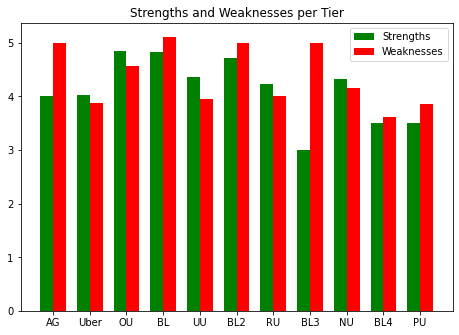

```python
fig = plt.figure()
ax = fig.add_axes([0, 0, 1, 1])

x = np.arange(len(list(tier_matchup_data.keys())))
width = 0.35
index = 0
for tier in tier_matchup_data.keys():
    ax.bar(x[index] - width/2, tier_matchup_data[tier][0], color = 'g', width = width)
    ax.bar(x[index] + width/2, tier_matchup_data[tier][1], color = 'r', width = width)
    index += 1

ax.set_title('Strengths and Weaknesses per Tier')
ax.set_xticks(x)
ax.legend(['Strengths', 'Weaknesses'])
ax.set_xticklabels(list(tier_matchup_data.keys()))
plt.show()
```

Unfortunately, it doesn't look like the average number of strengths and weaknesses at each tier has any distinguishable pattern that we can use to identify if a Pokémon is good or not. It is probably not worth using as a metric going forward.

## Making Predictions

Ultimately, the goal is to be able to predict what tier a new Pokémon will fall in. To do this, I first test out how a Logistic Regression Classifier model will be able to predict the tier. To convert the type into numerical data that can be used by a Logistic Regression Classifier, I seperate each type into its own column and have it be a binary 1 or 0 to indicate presence of the type.

```python
types = list(scores.keys())
types.append("None")
for type in types:
    df[type] = df.apply(lambda row: 1 if row['Type.1'] == type or row['Type.2'] == type else 0, axis=1)

types.append("Total")
```

Now, I fit a Logistic Regression Classifier on the data. In order to ensure that I was fairly testing the accuracy of the model, I split the data into training and testing data using sklearn's built in train_test_split function. I also make use of sklearn's make_pipeline function, to build a pipeline that first scales the data, then sends it to the Logistic Regression Classifier. This allows for the model to fit more easily on the data, since it is standardized.

```python
X = df[types]
y = df["Tier_Num"].to_numpy().reshape((-1, 1))
X_train, X_test, y_train, y_test = train_test_split(X, df["Tier"], test_size=0.33)

pipe = make_pipeline(StandardScaler(), LogisticRegression())
pipe.fit(X_train, y_train)

print(f"Score: {pipe.score(X_test, y_test)}")
```

```
Score: 0.44242424242424244
```

I noticed that the score was pretty low. I realized that this was because the scoring metric I was using was scoring 1 for an accurate answer, and 0 for anything else. However, if the guessed tier is close to the actual tier, it should be assigning a higher score than 0. To solve this problem, I implemented my own scoring function, where each prediction is weighted 1 if it is correct, and 3 / (3 + the difference in tiers) otherwise. I found that this had a good balancing in still giving points to tiers that were close, but with greatly diminished returns.

```python
def custom_scorer(ground_truth, predictions):
    ground_truth = ground_truth.to_numpy()
    score = 0
    for i in range (0, len(predictions)):
        if tier_to_num[ground_truth[i]] == tier_to_num[predictions[i]]:
            score += 1
        else:
            score += 3 / (3 + abs(tier_to_num[ground_truth[i]] - tier_to_num[predictions[i]]))

    return score * 1.0 / len(predictions)
```

With the new scorer implemented, all I have to do is make it into a scoring function through sklearn's make_scorer function, and the refit the data on the pipeline.

```python
new_scorer = make_scorer(custom_scorer)
X_train, X_test, y_train, y_test = train_test_split(X, df["Tier"], test_size=0.33)
pipe = make_pipeline(StandardScaler(), LogisticRegression(max_iter=1000))
pipe.fit(X_train, y_train)
print(f"Score: {new_scorer(pipe, X_test, y_test)}")
```

```
Score: 0.733543224452315
```

This is a much higher score than the model was getting before. While it might not be perfect at exactly predicting the tier a Pokémon will be in, it has a pretty good chance of at least getting close. Unfortunately, there are only a limited number of Pokémon to train the model on, so the model could be expected to become even more accurate with a larger sample size. This will have to wait until new Pokémon are released, though.

To better visualize the accuracy of the model, I plot the number of tiers off each prediction is for each tier on a violin plot.

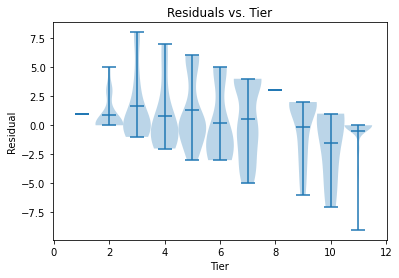

```python
tiers = []
residuals = []
for tier in df['Tier'].unique():
    tiers.append(tier_to_num[tier])
    mask = df['Tier'] == tier
    temp = []
    for index, row in df[mask].iterrows():
        data = row[types]
        temp.append(tier_to_num[pipe.predict([data])[0]] - tier_to_num[tier])
    residuals.append(temp)

fig, ax = plt.subplots()

ax.violinplot(residuals,tiers,widths=1,showmeans=True)
ax.set_xlabel("Tier")
ax.set_ylabel("Residual")
ax.set_title("Residuals vs. Tier")

fig.savefig("violin.png")
```

As a final test, I thought I would try to make up a couple of Pokémon to have the model predict what tier they will be, as a sort of test for new generations to come. I decided to try to make my personal estimate of an OU Pokémon, a UU Pokémon, and a NU Pokémon.

```python
# OU Pokémon: Dragon/Steel type, 600 BST (Base Stat Total)
ou_pokemon = np.array([[1, 1, 0, 0, 0, 0, 0, 0, 0, 0, 0, 0, 0, 0, 0, 0, 0, 0, 0, 600]])
# UU Pokémon: Fairy type, 600 BST
uu_pokemon = np.array([[0, 0, 0, 0, 0, 0, 1, 0, 0, 0, 0, 0, 0, 0, 0, 0, 0, 0, 1, 600]])
# NU Pokémon: Rock type, 500 BST
nu_pokemon = np.array([[0, 0, 0, 0, 0, 0, 0, 0, 0, 0, 0, 0, 0, 0, 0, 0, 0, 1, 1, 500]])
pokemon = np.concatenate((ou_pokemon, uu_pokemon, nu_pokemon), axis=0)
predictions = pipe.predict(pokemon)

print(f"OU Pokémon prediction: {predictions[0]}")
print(f"UU Pokémon prediction: {predictions[1]}")
print(f"NU Pokémon prediction: {predictions[2]}")
```

```
OU Pokémon prediction: OU
UU Pokémon prediction: UU
NU Pokémon prediction: PU
```

The model did great in predicting the first two, but slightly underestimated the NU Pokémon. However, this could have just as well been a misidentification on my part, where I expected the Pokémon to be higher tier than it actually is. Either way, because NU is fairly close to PU, I'd say that the model did a fairly good job in classifying the Pokémon.

## Conclusion

After training a Logistic Regression Classifier on the data, I determined that total base stats, as well as typing, do both have significant impact on the tier that a Pokémon will fall in. However, there are many other aspects that make a Pokémon "good."

Type and stats are simple to train a model on because stats are numeric and types are limited to certain values, but there are a number of other values that aren't so easily quantifiable for the sake of training a model that have weight on how well a Pokémon does. Abilities, held items, and moves, all have equal, if not greater in some circumstances, weight compared to stats and type. But Pokémon each can learn tens of moves, have hundreds of held items, and even multiple potential abilities sometimes. It is impossible to decide through code which is the best of those thousands of possibilities, and how that might be applied to another Pokémon. Take for example Mega Kangaskhan, an Uber Pokémon who sports unimpressive stats. However, it has an ability that allows it to hit twice in one turn, which skyrockets an otherwise average Pokémon to Ubers. Taking into account all these optimal abilities and held items would be a much greater scale than I could reasonably hope to accomplish in this project.

That being said, abilities, moves, and held items can only do so much for a Pokémon. While not the most accurate, measuring a Pokémon's "goodness" by stats and typing does a fairly good job in most cases. Besides for a couple of stragglers who were put in different tiers because of their ability or optimal movesets, the model was able to decently accurately predict most Pokémon. As different generations are released and "optimal" changes, types and stats will never change. For this reason, I consider this model successful.